# Tugas 1 Praktikum MPDW

Septiranny Rizqika Putri G1401211083

#Packages

```r
install.packages("forecast")
```

```r
install.packages("graphics")
install.packages("TTR")
install.packages("TSA")
library(forecast)
library(graphics)
library(TTR)
library(TSA)
```

#Impor data

```r
library(readxl)
gas <- read_excel("gasoline.xlsx")
gas
```

```
## # A tibble: 173 × 2
##    `Year-Week` Gasoline_Production
##    <chr>                     <dbl>
##  1 2020-01              2781240000
##  2 2020-02              2750076000
##  3 2020-03              2819460000
##  4 2020-04              2876496000
##  5 2020-05              2688630000
##  6 2020-06              2740374000
##  7 2020-07              2702448000
##  8 2020-08              2705976000
##  9 2020-09              2655408000
## 10 2020-10              2611308000
## # ℹ 163 more rows
```

Mengubah peubah respon Gasoline_Production menjadi dalam satuan ribu

```r
gas$Gasoline_Production <- gas$Gasoline_Production/1000
```

#Eksplorasi data

Melihat dimensi/ukuran data

```r
dim(gas)
```

```
## [1] 173   2
```

Melihat struktur data

```r
str(gas)
```

```
## tibble [173 × 2] (S3: tbl_df/tbl/data.frame)
##  $ Year-Week          : chr [1:173] "2020-01" "2020-02" "2020-03" "2020-04" ...
##  $ Gasoline_Production: num [1:173] 2781240 2750076 2819460 2876496 2688630 ...
```

Membuat data terbaca sebagai data time series

```r
gas.ts <- ts(gas$Gasoline_Production)
```

Menampilkan ringkasan data

```r
summary(gas.ts)
```

```
##    Min. 1st Qu.  Median    Mean 3rd Qu.    Max.
## 1489110 2450784 2576028 2539688 2696862 2952642
```

Menampilkan plot deret waktu data

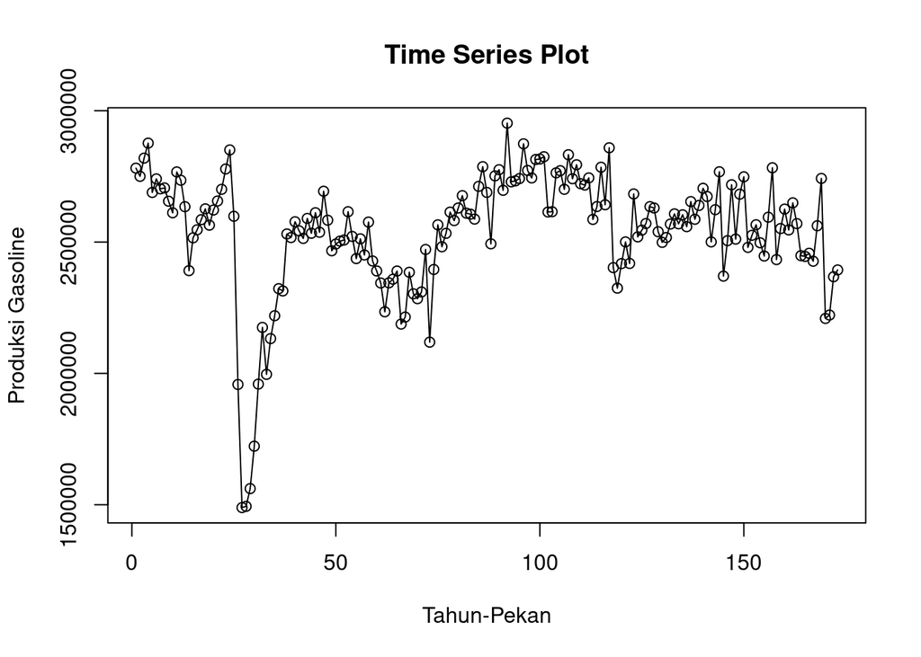

```r
ts.plot(gas.ts, xlab="Tahun-Pekan", ylab="Produksi Gasoline",
        main = "Time Series Plot")
points(gas.ts)
```

#Pemulusan

##Pembagian data

Data dibagi menjadi data latih dan data uji, dengan komposisi 80% data latih dan 20% data uji

```r
gas.train <- gas[1:138,]
gas.test <- gas[139:173,]
```

Membuat data terbaca sebagai data time series

```r
ts.train <- ts(gas.train$Gasoline_Production)
ts.test <- ts(gas.test$Gasoline_Production)
```

##Eksplorasi data

Menampilkan plot deret waktu data keseluruhan

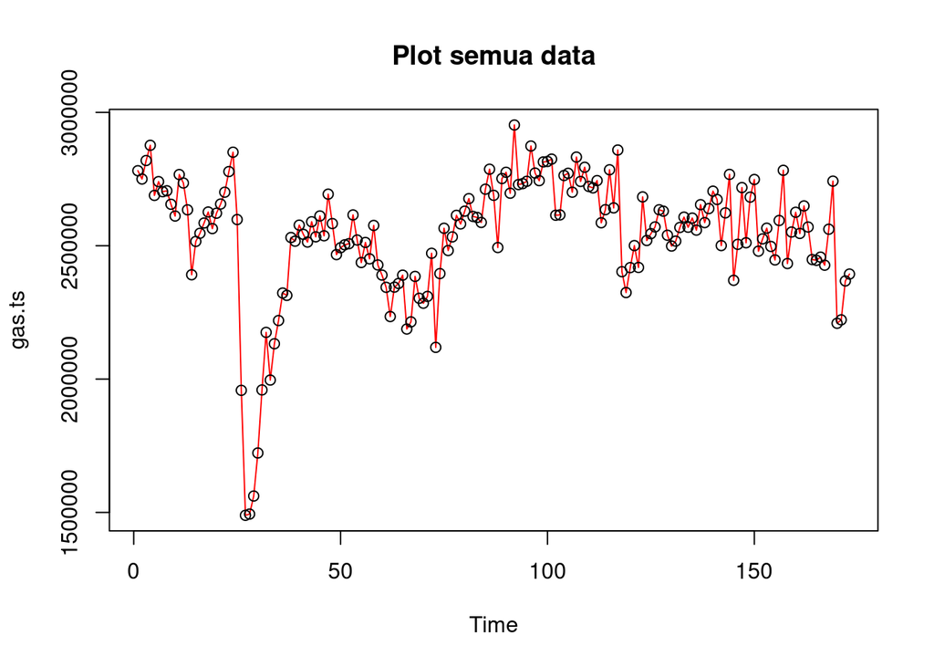

```r
plot(gas.ts, col="red",main="Plot semua data")
points(gas.ts)
```

Menampilkan plot deret waktu data latih

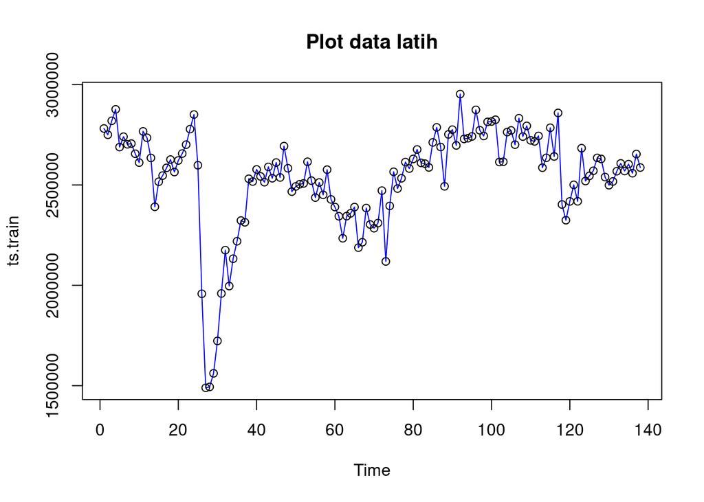

```r
plot(ts.train, col="blue",main="Plot data latih")
points(ts.train)
```

Menampilkan plot deret waktu data uji

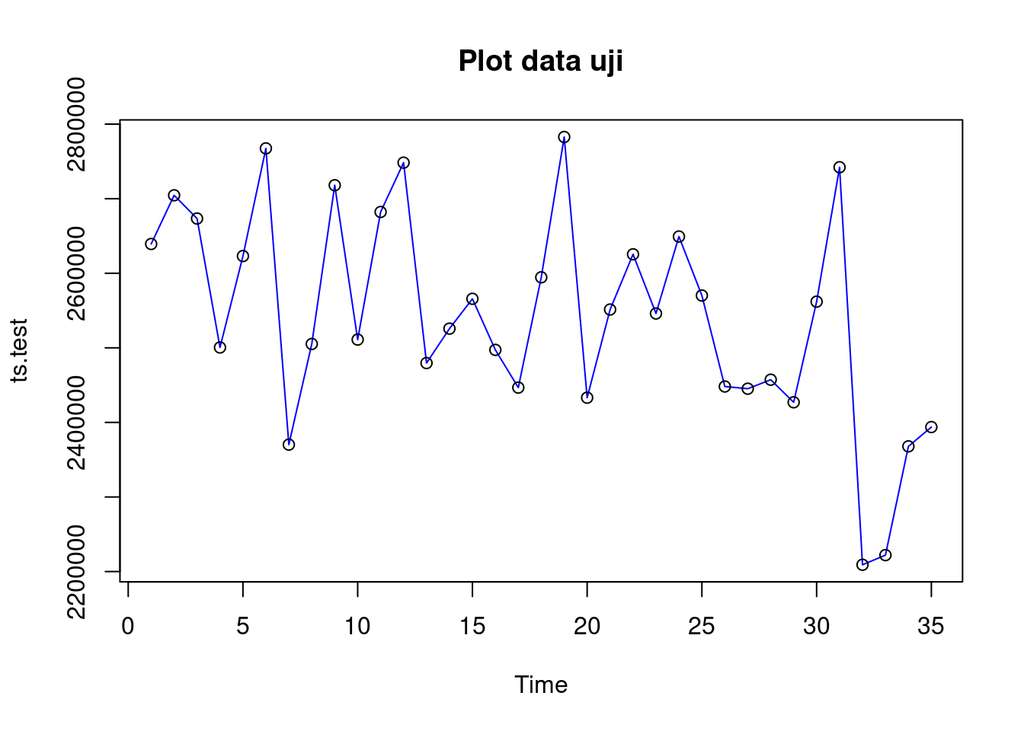

```r
plot(ts.test, col="blue",main="Plot data uji")
points(ts.test)
```

##Pemulusan dengan Single Moving Average

Pemulusan SMA dengan parameter $m=3$

```r
gas.sma<-SMA(ts.train, n=3)
gas.sma
```

```
## Time Series:
## Start = 1
## End = 138
## Frequency = 1
##   [1]      NA      NA 2783592 2815344 2794862 2768500 2710484 2716266 2687944
##  [10] 2657564 2677850 2704408 2712150 2586906 2513896 2484594 2549274 2586024
##  [19] 2591904 2604154 2614150 2659622 2711660 2776438 2742236 2468816 2014978
##  [28] 1646890 1514786 1592696 1747830 1952356 2043496 2101218 2116016 2224796
##  [37] 2285262 2389044 2453822 2541630 2545550 2544472 2548686 2545648 2578282
##  [46] 2560740 2614052 2604546 2581026 2514092 2487534 2501156 2542120 2548098
##  [55] 2524578 2490180 2466660 2513014 2484888 2464602 2387280 2322796 2307704
##  [64] 2312506 2364250 2311918 2263898 2262330 2300746 2324070 2299080 2355332
##  [73] 2300158 2328676 2359938 2480968 2526832 2543002 2576224 2608368 2629242
##  [82] 2638650 2630810 2601018 2635024 2695294 2729202 2656290 2644628 2673440
##  [91] 2741354 2808288 2792902 2804858 2734494 2782710 2795940 2796724 2776830
## [100] 2791334 2818284 2751644 2684808 2664326 2716756 2745176 2768206 2758014
## [109] 2789178 2752428 2744392 2727732 2682358 2655114 2668638 2687258 2761836
## [118] 2634436 2528596 2381596 2414230 2445590 2533986 2540356 2582594 2545060
## [127] 2583476 2611602 2601214 2555840 2518404 2528106 2564268 2581614 2593374
## [136] 2577106 2605330 2599646
```

Hasil peramalan 1 periode ke depan

```r
ramal.sma<-c(NA,gas.sma)
ramal.sma
```

```
##   [1]      NA      NA      NA 2783592 2815344 2794862 2768500 2710484 2716266
##  [10] 2687944 2657564 2677850 2704408 2712150 2586906 2513896 2484594 2549274
##  [19] 2586024 2591904 2604154 2614150 2659622 2711660 2776438 2742236 2468816
##  [28] 2014978 1646890 1514786 1592696 1747830 1952356 2043496 2101218 2116016
##  [37] 2224796 2285262 2389044 2453822 2541630 2545550 2544472 2548686 2545648
##  [46] 2578282 2560740 2614052 2604546 2581026 2514092 2487534 2501156 2542120
##  [55] 2548098 2524578 2490180 2466660 2513014 2484888 2464602 2387280 2322796
##  [64] 2307704 2312506 2364250 2311918 2263898 2262330 2300746 2324070 2299080
##  [73] 2355332 2300158 2328676 2359938 2480968 2526832 2543002 2576224 2608368
##  [82] 2629242 2638650 2630810 2601018 2635024 2695294 2729202 2656290 2644628
##  [91] 2673440 2741354 2808288 2792902 2804858 2734494 2782710 2795940 2796724
## [100] 2776830 2791334 2818284 2751644 2684808 2664326 2716756 2745176 2768206
## [109] 2758014 2789178 2752428 2744392 2727732 2682358 2655114 2668638 2687258
## [118] 2761836 2634436 2528596 2381596 2414230 2445590 2533986 2540356 2582594
## [127] 2545060 2583476 2611602 2601214 2555840 2518404 2528106 2564268 2581614
## [136] 2593374 2577106 2605330 2599646
```

Selanjutnya, dilakukan peramalan sejumlah data uji, yaitu 35 periode. Pada metode SMA, hasil peramalan 35 periode ke depan akan bernilai sama dengan hasil peramalan 1 periode ke depan.

Penggabungan data train aktual, data train hasil pemulusan, dan data hasil ramalan 35 periode ke depan

```r
data.gab<-cbind(aktual=c(ts.train,rep(NA,35)),pemulusan=c(gas.sma,rep(NA,35)),ramalan=c(ramal.sma,rep(ramal.sma[length(ramal.sma)],34)))
data.gab
```

```
##         aktual pemulusan ramalan
##   [1,] 2781240        NA      NA
##   [2,] 2750076        NA      NA
##   [3,] 2819460   2783592      NA
##   [4,] 2876496   2815344 2783592
##   [5,] 2688630   2794862 2815344
##   [6,] 2740374   2768500 2794862
##   [7,] 2702448   2710484 2768500
##   [8,] 2705976   2716266 2710484
##   [9,] 2655408   2687944 2716266
##  [10,] 2611308   2657564 2687944
##  [11,] 2766834   2677850 2657564
##  [12,] 2735082   2704408 2677850
##  [13,] 2634534   2712150 2704408
##  [14,] 2391102   2586906 2712150
```

[output cut: 159 more lines]

Menampilkan plot deret waktu data hasil peramalan

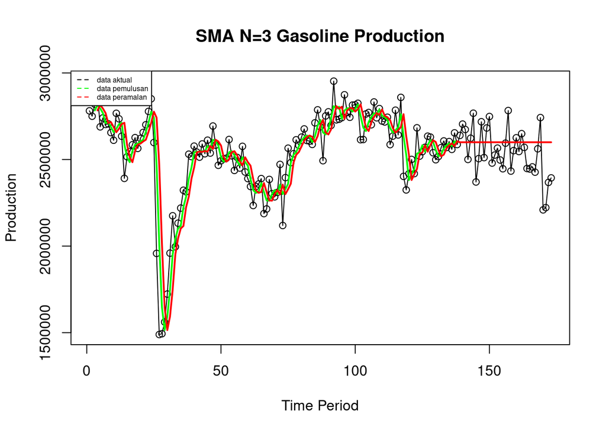

```r
ts.plot(gas.ts, xlab="Time Period", ylab="Production", main= "SMA N=3 Gasoline Production")
points(gas.ts)
lines(data.gab[,2],col="green",lwd=2)
lines(data.gab[,3],col="red",lwd=2)
legend("topleft",c("data aktual","data pemulusan","data peramalan"), lty=8, col=c("black","green","red"), cex=0.5)
```

Perhitungan akurasi dengan ukuran akurasi *Sum Squares Error* (SSE), *Mean Square Error* (MSE), dan *Mean Absolute Percentage Error* (MAPE).

Perhitungan akurasi pada data latih

```r
#Akurasi data latih
error_train.sma = ts.train-ramal.sma[1:length(ts.train)]
SSE_train.sma = sum(error_train.sma[4:length(ts.train)]^2)
MSE_train.sma = mean(error_train.sma[4:length(ts.train)]^2)
MAPE_train.sma = mean(abs((error_train.sma[4:length(ts.train)]/ts.train[4:length(ts.train)])*100))

akurasi_train.sma <- matrix(c(SSE_train.sma, MSE_train.sma, MAPE_train.sma))
row.names(akurasi_train.sma)<- c("SSE", "MSE", "MAPE")
colnames(akurasi_train.sma) <- c("Akurasi m = 3")
akurasi_train.sma
```

```
##      Akurasi m = 3
## SSE   3.764829e+12
## MSE   2.788762e+10
## MAPE  4.644038e+00
```

MAPE data latih pada metode pemulusan SMA dengan m=3 berkisar 4,6%. Ini menunjukkan akurasinya sangat baik.

Penghitungan akurasi pada data uji

```r
#Akurasi data uji
error_test.sma = ts.test-data.gab[139:173,3]
SSE_test.sma = sum(error_test.sma^2)
MSE_test.sma = mean(error_test.sma^2)
MAPE_test.sma = mean(abs((error_test.sma/ts.test*100)))

akurasi_test.sma <- matrix(c(SSE_test.sma, MSE_test.sma, MAPE_test.sma))
row.names(akurasi_test.sma)<- c("SSE", "MSE", "MAPE")
colnames(akurasi_test.sma) <- c("Akurasi m = 3")
akurasi_test.sma
```

```
##      Akurasi m = 3
## SSE   8.040649e+11
## MSE   2.297328e+10
## MAPE  5.002304e+00
```

MAPE data uji pada metode pemulusan SMA dengan m=3 berkisar 5%. Ini menunjukkan akurasinya sangat baik.

##Pemulusan dengan Double Moving Average

```r
dma <- SMA(gas.sma, n=3)
At <- 2*gas.sma - dma
Bt <- 2/(3-1)*(gas.sma - dma)
gas.dma<- At+Bt
ramal.dma<- c(NA, gas.dma)

t = 1:35
f = c()

for (i in t) {
  f[i] = At[length(At)] + Bt[length(Bt)]*(i)
}

data.gab2 <- cbind(aktual = c(ts.train,rep(NA,35)), pemulusan1 = c(gas.sma,rep(NA,35)), pemulusan2 = c(gas.dma, rep(NA,35)), At = c(At, rep(NA,35)), Bt = c(Bt,rep(NA,35)), ramalan = c(ramal.dma, f[-1]))

options(max.print=1500) #Agar semua 173 amatan dapat ditampilkan
data.gab2
```

```
##         aktual pemulusan1 pemulusan2      At            Bt   ramalan
##   [1,] 2781240         NA         NA      NA            NA        NA
##   [2,] 2750076         NA         NA      NA            NA        NA
##   [3,] 2819460    2783592         NA      NA            NA        NA
##   [4,] 2876496    2815344         NA      NA            NA        NA
##   [5,] 2688630    2794862  2788720.7 2791791   -3070.66667        NA
##   [6,] 2740374    2768500  2719696.0 2744098  -24402.00000 2788720.7
##   [7,] 2702448    2710484  2615554.7 2663019  -47464.66667 2719696.0
##   [8,] 2705976    2716266  2685298.0 2700782  -15484.00000 2615554.7
##   [9,] 2655408    2687944  2654036.0 2670990  -16954.00000 2685298.0
##  [10,] 2611308    2657564  2598176.0 2627870  -29694.00000 2654036.0
##  [11,] 2766834    2677850  2684644.7 2681247    3397.33333 2598176.0
##  [12,] 2735082    2704408  2753342.7 2728875   24467.33333 2684644.7
##  [13,] 2634534    2712150  2740178.0 2726164   14014.00000 2753342.7
##  [14,] 2391102    2586906  2425075.3 2505991  -80915.33333 2740178.0
```

[output cut: 159 more lines]

Visualisasi hasil pemulusan dengan DMA

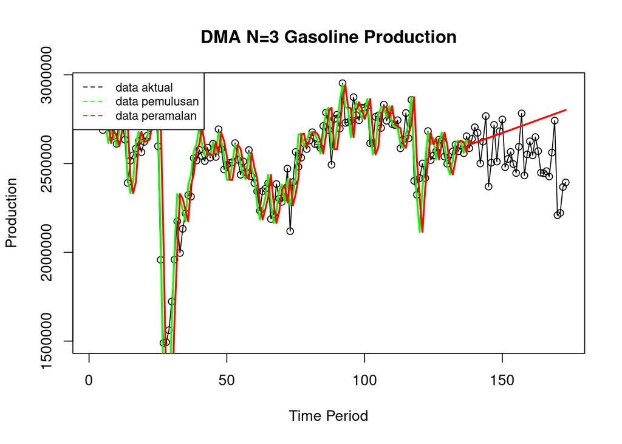

```r
ts.plot(gas.ts, xlab="Time Period", ylab="Production", main= "DMA N=3 Gasoline Production")
points(gas.ts)
lines(data.gab2[,3],col="green",lwd=2)
lines(data.gab2[,6],col="red",lwd=2)
legend("topleft",c("data aktual","data pemulusan","data peramalan"), lty=8, col=c("black","green","red"), cex=0.8)
```

Selanjutnya, dilakukan perhitungan akurasi dengan ukuran akurasi SSE, MSE, dan MAPE.

Perhitungan akurasi pada data latih

```r
#Akurasi data latih
error_train.dma = ts.train-ramal.dma[1:length(ts.train)]
SSE_train.dma = sum(error_train.dma[6:length(ts.train)]^2)
MSE_train.dma = mean(error_train.dma[6:length(ts.train)]^2)
MAPE_train.dma = mean(abs((error_train.dma[6:length(ts.train)]/ts.train[6:length(ts.train)])*100))

akurasi_train.dma <- matrix(c(SSE_train.dma, MSE_train.dma, MAPE_train.dma))
row.names(akurasi_train.dma)<- c("SSE", "MSE", "MAPE")
colnames(akurasi_train.dma) <- c("Akurasi m = 3")
akurasi_train.dma
```

```
##      Akurasi m = 3
## SSE   4.437423e+12
## MSE   3.336408e+10
## MAPE  5.547833e+00
```

MAPE data latih pada metode pemulusan DMA dengan m=3 berkisar 5,5%. Ini menunjukkan akurasinya sangat baik.

Penghitungan akurasi data uji

```r
#Akurasi data uji
error_test.dma = ts.test-data.gab2[139:173,6]
SSE_test.dma = sum(error_test.dma^2)
MSE_test.dma = mean(error_test.dma^2)
MAPE_test.dma = mean(abs((error_test.dma/ts.test*100)))

akurasi_test.dma <- matrix(c(SSE_test.dma, MSE_test.dma, MAPE_test.dma))
row.names(akurasi_test.dma)<- c("SSE", "MSE", "MAPE")
colnames(akurasi_test.dma) <- c("Akurasi m = 3")
akurasi_test.dma
```

```
##      Akurasi m = 3
## SSE   2.019922e+12
## MSE   5.771206e+10
## MAPE  7.933867e+00
```

MAPE data uji pada metode pemulusan DMA dengan m=3 berkisar 7,9%. Ini menunjukkan akurasinya sangat baik.

Baik pada data latih maupun data uji, metode SMA memiliki akurasi yang lebih baik.

##Pemulusan dengan Single Exponential Smoothing

Pemulusan dengan metode SES dapat dilakukan dengan dua fungsi dari *packages* berbeda, yaitu (1) fungsi `ses()` dari *packages* `forecast` dan (2) fungsi `HoltWinters` dari *packages* `stats`.

Pemulusan dengan SES menggunakan fungsi `ses()`

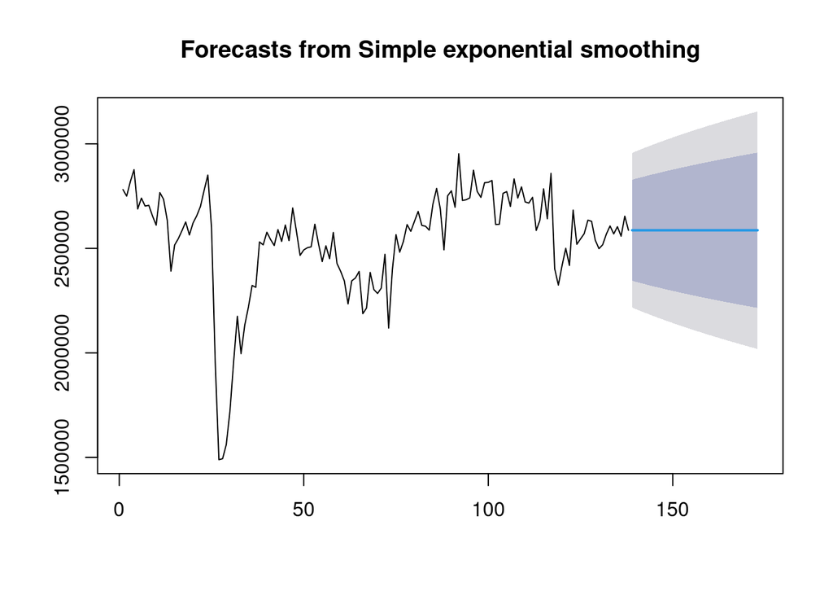

```r
#Cara 1 (fungsi ses)
ses1 <- ses(ts.train, h = 35, alpha = 0.2)
plot(ses1)
```

```r
ses1
```

```
##     Point Forecast   Lo 80   Hi 80   Lo 95   Hi 95
## 139        2586738 2344952 2828524 2216959 2956518
## 140        2586738 2340164 2833313 2209636 2963841
## 141        2586738 2335467 2838010 2202452 2971025
## 142        2586738 2330856 2842621 2195400 2978076
## 143        2586738 2326327 2847150 2188473 2985003
## 144        2586738 2321875 2851602 2181665 2991812
## 145        2586738 2317497 2855980 2174969 2998508
## 146        2586738 2313189 2860288 2168380 3005096
## 147        2586738 2308947 2864529 2161894 3011583
## 148        2586738 2304770 2868707 2155505 3017972
## 149        2586738 2300653 2872823 2149209 3024268
## 150        2586738 2296595 2876881 2143003 3030474
## 151        2586738 2292593 2880884 2136882 3036595
## 152        2586738 2288645 2884832 2130843 3042633
```

[output cut: 21 more lines]

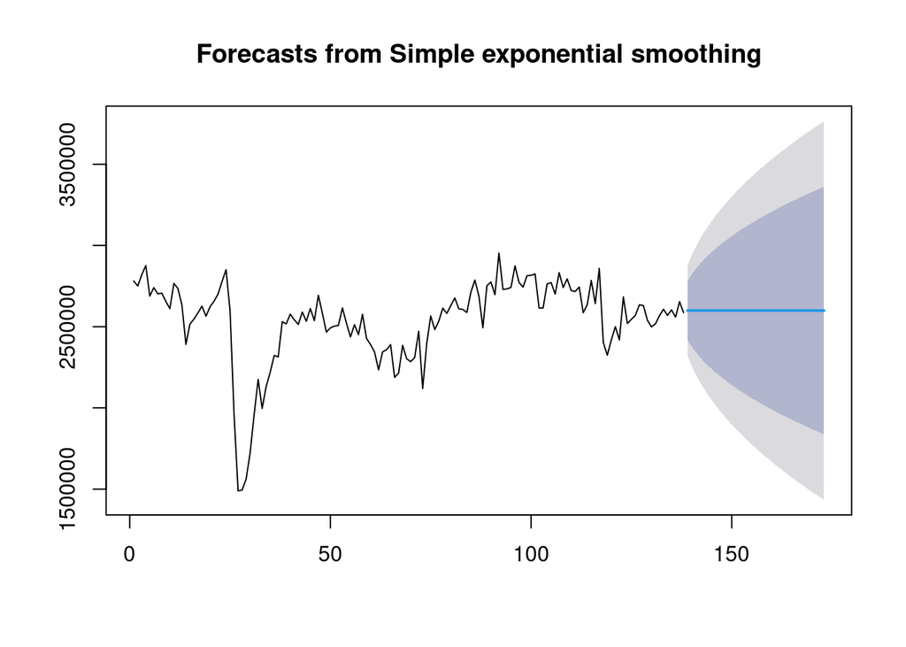

```r
ses2<- ses(ts.train, h = 35, alpha = 0.7)
plot(ses2)
```

```r
ses2
```

```
##     Point Forecast   Lo 80   Hi 80   Lo 95   Hi 95
## 139        2599207 2417858 2780556 2321858 2876556
## 140        2599207 2377843 2820571 2260660 2937754
## 141        2599207 2344027 2854387 2208943 2989471
## 142        2599207 2314195 2884219 2163319 3035095
## 143        2599207 2287203 2911211 2122038 3076376
## 144        2599207 2262367 2936047 2084054 3114359
## 145        2599207 2239240 2959174 2048685 3149728
## 146        2599207 2217512 2980902 2015455 3182959
## 147        2599207 2196956 3001458 1984018 3214396
## 148        2599207 2177401 3021013 1954110 3244304
## 149        2599207 2158713 3039701 1925529 3272885
## 150        2599207 2140786 3057628 1898112 3300302
## 151        2599207 2123534 3074880 1871728 3326686
## 152        2599207 2106886 3091527 1846268 3352146
```

[output cut: 21 more lines]

Visualisasi hasil pemulusan dengan SES

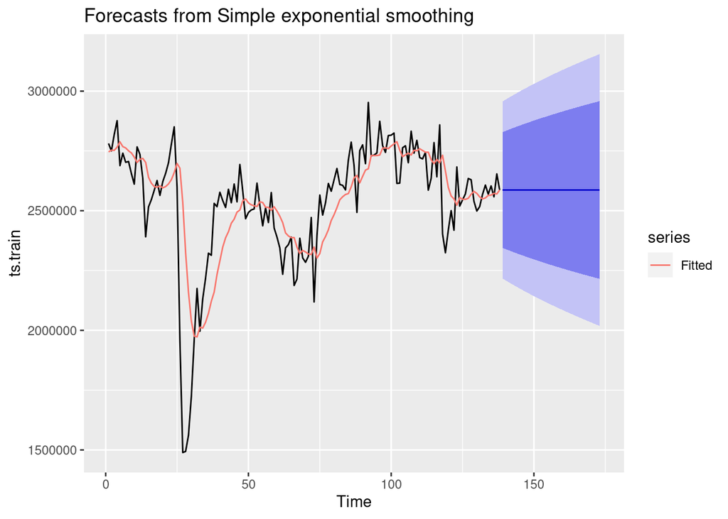

```r
autoplot(ses1) + autolayer(fitted(ses1), series="Fitted")
```

Pemulusan dengan SES menggunakan fungsi `HoltWinters()`

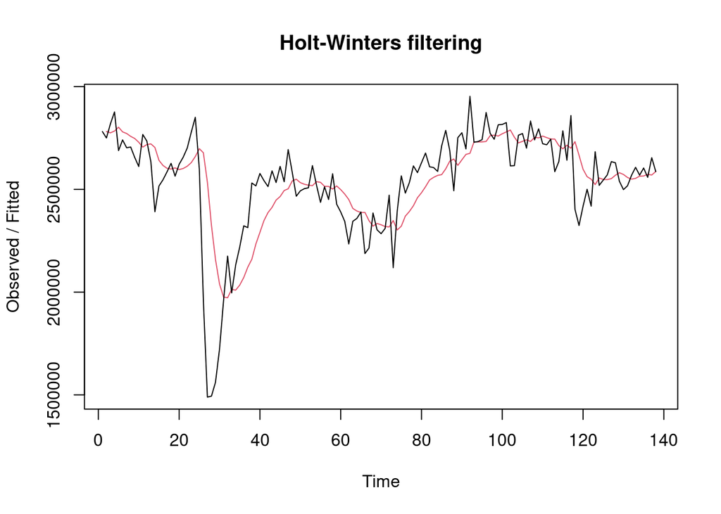

```r
#Cara 2 (fungsi Holtwinter)
ses.hw1<- HoltWinters(ts.train, gamma = FALSE, beta = FALSE, alpha = 0.2)
plot(ses.hw1)
```

```r
#ramalan
ramalan.hw1<- forecast(ses.hw1, h=35)
ramalan.hw1
```

```
##     Point Forecast   Lo 80   Hi 80   Lo 95   Hi 95
## 139        2586738 2345039 2828438 2217091 2956386
## 140        2586738 2340252 2833224 2209770 2963706
## 141        2586738 2335557 2837920 2202589 2970887
## 142        2586738 2330948 2842529 2195540 2977936
## 143        2586738 2326420 2847057 2188616 2984861
## 144        2586738 2321970 2851507 2181810 2991667
## 145        2586738 2317593 2855883 2175116 2998360
## 146        2586738 2313287 2860190 2168530 3004947
## 147        2586738 2309047 2864430 2162046 3011431
## 148        2586738 2304871 2868606 2155659 3017818
## 149        2586738 2300756 2872721 2149366 3024111
## 150        2586738 2296699 2876778 2143161 3030315
## 151        2586738 2292698 2880778 2137043 3036434
## 152        2586738 2288751 2884725 2131006 3042470
```

[output cut: 21 more lines]

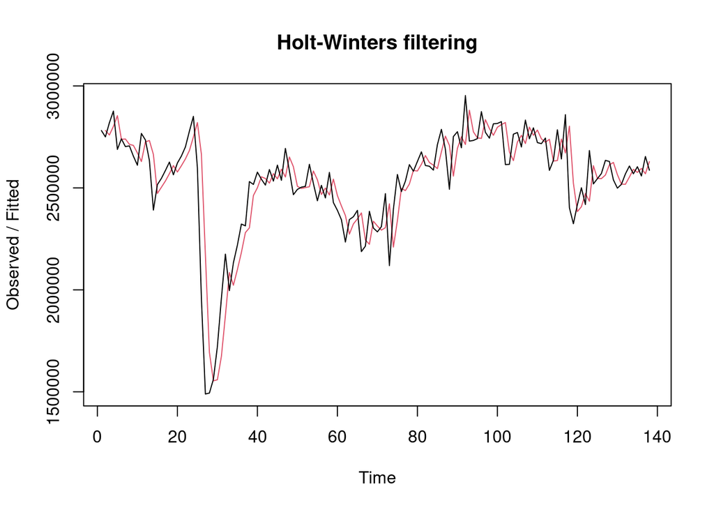

```r
ses.hw2<- HoltWinters(ts.train, gamma = FALSE, beta = FALSE, alpha = 0.7)
plot(ses.hw2)
```

```r
#ramalan
ramalan.hw2<- forecast(ses.hw2, h=35)
ramalan.hw2
```

```
##     Point Forecast   Lo 80   Hi 80   Lo 95   Hi 95
## 139        2599207 2417874 2780539 2321883 2876531
## 140        2599207 2377862 2820551 2260690 2937724
## 141        2599207 2344049 2854364 2208977 2989437
## 142        2599207 2314221 2884193 2163358 3035056
## 143        2599207 2287231 2911183 2122080 3076333
## 144        2599207 2262397 2936017 2084100 3114314
## 145        2599207 2239272 2959142 2048734 3149680
## 146        2599207 2217546 2980868 2015507 3182907
## 147        2599207 2196992 3001422 1984072 3214342
## 148        2599207 2177438 3020976 1954167 3244246
## 149        2599207 2158752 3039662 1925589 3272825
## 150        2599207 2140826 3057587 1898175 3300239
## 151        2599207 2123576 3074838 1871793 3326621
## 152        2599207 2106930 3091484 1846334 3352079
```

[output cut: 21 more lines]

Pemulusan dengan nilai parameter alpha ($\alpha$) yang dioptimalkan

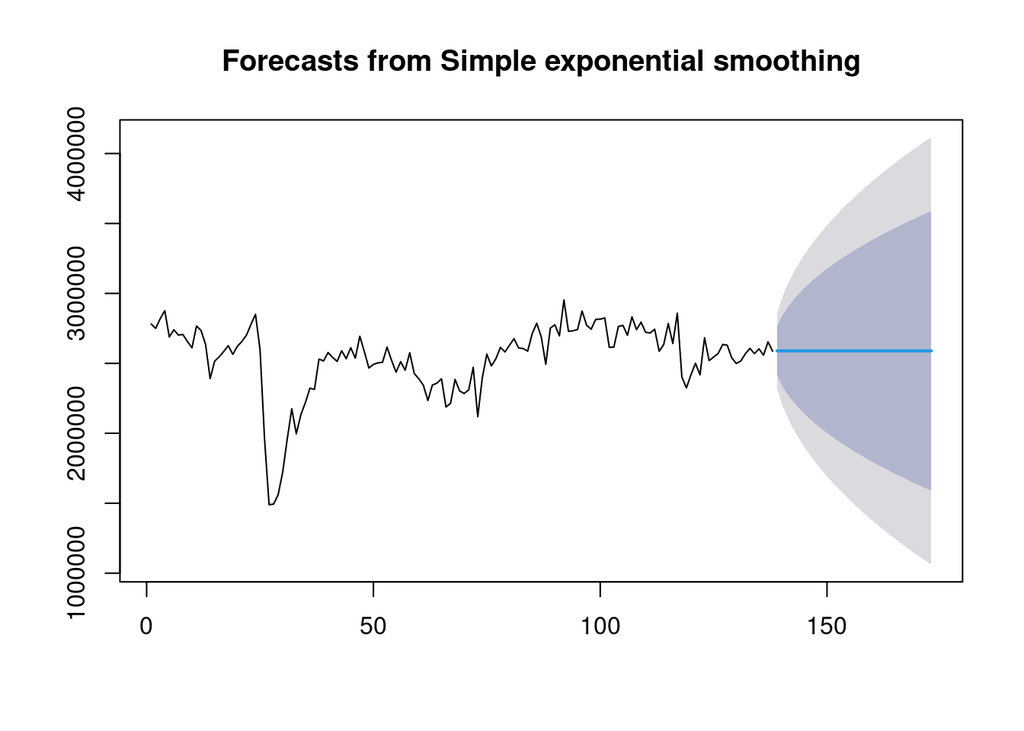

```r
#Menggunakan fungsi ses
ses.opt <- ses(ts.train, h=35, alpha = NULL)
plot(ses.opt)
```

```r
ses.opt
```

```
##     Point Forecast   Lo 80   Hi 80   Lo 95   Hi 95
## 139        2589117 2413400 2764834 2320381 2857853
## 140        2589117 2345457 2832776 2216472 2961762
## 141        2589117 2292699 2885534 2135785 3042448
## 142        2589117 2248006 2930228 2067432 3110801
## 143        2589117 2208525 2969709 2007052 3171182
## 144        2589117 2172771 3005462 1952371 3225863
## 145        2589117 2139854 3038380 1902028 3276205
## 146        2589117 2109189 3069045 1855131 3323103
## 147        2589117 2080369 3097864 1811055 3367179
## 148        2589117 2053097 3125137 1769345 3408889
## 149        2589117 2027146 3151087 1729657 3448577
## 150        2589117 2002342 3175891 1691722 3486511
## 151        2589117 1978545 3199689 1655328 3522906
## 152        2589117 1955641 3222592 1620299 3557934
```

[output cut: 21 more lines]

```r
#Lambda Optimum Holt Winter
seshw.opt<- HoltWinters(ts.train, gamma = FALSE, beta = FALSE,alpha = NULL)
seshw.opt
```

```
## Holt-Winters exponential smoothing without trend and without seasonal component.
##
## Call:
## HoltWinters(x = ts.train, alpha = NULL, beta = FALSE, gamma = FALSE)
##
## Smoothing parameters:
##  alpha: 0.9608706
##  beta : FALSE
##  gamma: FALSE
##
## Coefficients:
##      [,1]
## a 2589103
```

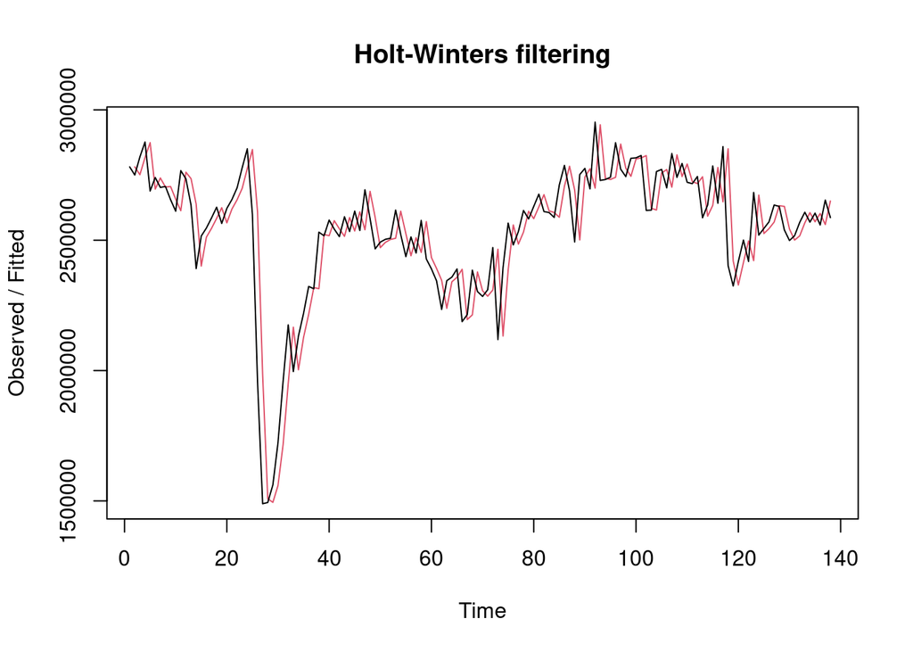

```r
plot(seshw.opt)
```

```r
#Ramalan Holt Winter
ramalanopt<- forecast(seshw.opt, h=35)
ramalanopt
```

```
##     Point Forecast   Lo 80   Hi 80   Lo 95   Hi 95
## 139        2589103 2413436 2764770 2320443 2857762
## 140        2589103 2345484 2832721 2216520 2961685
## 141        2589103 2292723 2885483 2135828 3042377
## 142        2589103 2248027 2930178 2067473 3110733
## 143        2589103 2208546 2969660 2007091 3171114
## 144        2589103 2172792 3005414 1952410 3225795
## 145        2589103 2139875 3038331 1902068 3276138
## 146        2589103 2109210 3068996 1855170 3323035
## 147        2589103 2080390 3097815 1811094 3367111
## 148        2589103 2053118 3125087 1769385 3408820
## 149        2589103 2027168 3151037 1729698 3448508
## 150        2589103 2002365 3175841 1691764 3486441
## 151        2589103 1978568 3199638 1655370 3522835
## 152        2589103 1955664 3222541 1620342 3557863
```

[output cut: 21 more lines]

###Perhitungan akurasi data latih

Cara langsung

```r
#Akurasi data latih secara langsung
SSE1<-ses.hw1$SSE
MSE1<-ses.hw1$SSE/length(ts.train)
RMSE1<-sqrt(MSE1)

akurasi1 <- matrix(c(SSE1,MSE1,RMSE1))
row.names(akurasi1)<- c("SSE", "MSE", "RMSE")
colnames(akurasi1) <- c("Akurasi lambda=0.2")
akurasi1
```

```
##      Akurasi lambda=0.2
## SSE        4.844370e+12
## MSE        3.510413e+10
## RMSE       1.873610e+05
```

```r
SSE2<-ses.hw2$SSE
MSE2<-ses.hw2$SSE/length(ts.train)
RMSE2<-sqrt(MSE2)

akurasi2 <- matrix(c(SSE2,MSE2,RMSE2))
row.names(akurasi2)<- c("SSE", "MSE", "RMSE")
colnames(akurasi2) <- c("Akurasi lambda=0.7")
akurasi2
```

```
##      Akurasi lambda=0.7
## SSE        2.723308e+12
## MSE        1.973411e+10
## RMSE       1.404782e+05
```

Baik dilihat dari SSE, MSE, maupun RMSE, nilai pada $\lambda=0,2$ lebih besar dibandingkan nilai pada $\lambda=0,7$. Ini menunjukkan bahwa dengan parameter $\lambda=0,7$ menghasilkan akurasi yang lebih baik.

Cara manual

```r
#Akurasi data latih secara manual
fitted1<-ramalan.hw1$fitted
sisaan1<-ramalan.hw1$residuals
head(sisaan1)
```

```
## Time Series:
## Start = 1
## End = 6
## Frequency = 1
## [1]         NA  -31164.00   44452.80   92598.24 -113787.41  -39285.93
```

```r
resid1<-gas.train$Gasoline_Production-ramalan.hw1$fitted
head(resid1)
```

```
## Time Series:
## Start = 1
## End = 6
## Frequency = 1
## [1]         NA  -31164.00   44452.80   92598.24 -113787.41  -39285.93
```

```r
SSE.1=sum(sisaan1[2:length(ts.train)]^2)

MSE.1 = SSE.1/length(ts.train)

MAPE.1 = sum(abs(sisaan1[2:length(ts.train)]/ts.train[2:length(ts.train)])*100)/length(ts.train)

akurasi.1 <- matrix(c(SSE.1,MSE.1,MAPE.1))
row.names(akurasi.1)<- c("SSE", "MSE", "MAPE")
colnames(akurasi.1) <- c("Akurasi lambda=0.2")
akurasi.1
```

```
##      Akurasi lambda=0.2
## SSE        4.844370e+12
## MSE        3.510413e+10
## MAPE       5.242171e+00
```

```r
fitted2<-ramalan.hw2$fitted
sisaan2<-ramalan.hw2$residuals
head(sisaan2)
```

```
## Time Series:
## Start = 1
## End = 6
## Frequency = 1
## [1]         NA  -31164.00   60034.80   75046.44 -165352.07    2138.38
```

```r
resid2<-gas.train$Gasoline_Production-ramalan.hw2$fitted
head(resid2)
```

```
## Time Series:
## Start = 1
## End = 6
## Frequency = 1
## [1]         NA  -31164.00   60034.80   75046.44 -165352.07    2138.38
```

```r
SSE.2=sum(sisaan2[2:length(ts.train)]^2)

MSE.2 = SSE.2/length(ts.train)

MAPE.2 = sum(abs(sisaan2[2:length(ts.train)]/ts.train[2:length(ts.train)])*100)/length(ts.train)

akurasi.2 <- matrix(c(SSE.2,MSE.2,MAPE.2))
row.names(akurasi.2)<- c("SSE", "MSE", "MAPE")
colnames(akurasi.2) <- c("Akurasi lambda=0.7")
akurasi.2
```

```
##      Akurasi lambda=0.7
## SSE        2.723308e+12
## MSE        1.973411e+10
## MAPE       4.023509e+00
```

Parameter $\lambda=0,2$ menghasilkan MAPE senilai 5,2%, sedangkan parameter $\lambda=0,7$ menghasilkan MAPE senilai 4%. Ini menunjukkan bahwa keduanya memiliki akurasi yang tinggi, namun parameter $\lambda=0,7$ lebih baik.

###Perhitungan akurasi data uji

Cara manual

```r
#Akurasi data uji
selisih1<-ramalan.hw1$mean-gas.test$Gasoline_Production
SSEtesting1<-sum(selisih1^2)
MSEtesting1<-SSEtesting1/length(gas.test)

selisih2<-ramalan.hw2$mean-gas.test$Gasoline_Production
SSEtesting2<-sum(selisih2^2)
MSEtesting2<-SSEtesting2/length(gas.test)

selisihopt<-ramalanopt$mean-gas.test$Gasoline_Production
SSEtestingopt<-sum(selisihopt^2)
MSEtestingopt<-SSEtestingopt/length(gas.test)

akurasitesting1 <- matrix(c(SSEtesting1,SSEtesting2,SSEtestingopt))
row.names(akurasitesting1)<- c("SSE1", "SSE2", "SSEopt")
akurasitesting1
```

```
##                [,1]
## SSE1   758197565267
## SSE2   802312971941
## SSEopt 765727132585
```

```r
akurasitesting2 <- matrix(c(MSEtesting1,MSEtesting2,MSEtestingopt))
row.names(akurasitesting2)<- c("MSE1", "MSE2", "MSEopt")
akurasitesting2
```

```
##                [,1]
## MSE1   379098782634
## MSE2   401156485971
## MSEopt 382863566293
```

Baik dari SSE maupun MSE, nilai terkecil ada di ramalan pertama, yaitu ramalan dengan parameter $\lambda=0,2$. Sehingga, itulah yang akurasinya paling baik.

Melihat akurasi data dengan cara lain

```r
#Akurasi data dengan cara lain
ak1 <- accuracy(ramalan.hw1,gas.test$Gasoline_Production)
ak1
```

```
##                      ME     RMSE      MAE        MPE     MAPE     MASE
## Training set  -7098.602 188043.5 118651.8 -0.9789966 5.280435 1.220102
## Test set     -44310.303 147182.8 119883.7 -2.0610609 4.838623 1.232769
##                   ACF1
## Training set 0.6944115
## Test set            NA
```

```r
ak2 <- accuracy(ramalan.hw2,gas.test$Gasoline_Production)
ak2
```

```
##                      ME     RMSE       MAE        MPE     MAPE     MASE
## Training set  -1898.155 140989.9  95424.57 -0.3419462 4.052878 0.981255
## Test set     -56778.897 151404.2 123356.00 -2.5530156 4.996151 1.268475
##                   ACF1
## Training set 0.2501966
## Test set            NA
```

```r
ak.opt <- accuracy(ramalanopt,gas.test$Gasoline_Production)
ak.opt
```

```
##                      ME     RMSE       MAE        MPE     MAPE      MASE
## Training set  -1459.574 136580.3  96763.63 -0.2423684 4.032379 0.9950246
## Test set     -46674.762 147911.9 120491.68 -2.1543519 4.866551 1.2390212
##                     ACF1
## Training set 0.001145525
## Test set              NA
```

Seperti pengujian akurasi dengan cara lain sebelumnya, fungsi `accuracy()` juga menunjukkan bahwa yang paling akurat untuk digunakan adalah yang menggunakan nilai parameter $\lambda=0,2$